# Umid Mirjavharov MSDS - 660 Statistical Methods and Experimental Design

## Week 2: Boston Housing Data Set

23 May 2018

#### Use the Boston housing data set from MASS package (or a similar data set (housing) with a more recent data, and link to the data source)

Describe your data set such as what is this data set about? How many observations? How many variables? etc.,What are those variables?

Boston data set is a data set about Housing values in suburbs of Boston. It has 506 obervations and 14 variables.

Variables are:

crime- per capita crime rate y town, zn- poroportion of residential land zoned for lots over 25,000 sq.ft., indus- proportion of non-retail business acres per town, chas - Charles River dummy variable (= 1 if tract bounds river; 0 otherwise), nox- nitrogen oxides concentration (parts per 10 million), rm - average number of rooms per dwelling, age- proportion of owner-occupied units built prior to 1940, dis- weighted mean of distances to five Boston employment centres, rad - index of accessibility to radial highways, tax - full-value property-tax rate per $10,000, ptratio - pupil-teacher ratio by town, black - 1000(Bk - 0.63)^2 where Bk is the proportion of blacks by town, lstat - lower status of the population (percent), medv - median value of owner-occupied homes in $1000s.

```r
library(MASS)
str(Boston)
```

```
'data.frame':   506 obs. of  14 variables:
 $ crim   : num  0.00632 0.02731 0.02729 0.03237 0.06905 ...
 $ zn     : num  18 0 0 0 0 0 12.5 12.5 12.5 12.5 ...
 $ indus  : num  2.31 7.07 7.07 2.18 2.18 2.18 7.87 7.87 7.87 7.87 ...
 $ chas   : int  0 0 0 0 0 0 0 0 0 0 ...
 $ nox    : num  0.538 0.469 0.469 0.458 0.458 0.458 0.524 0.524 0.524 0.524 ...
 $ rm     : num  6.58 6.42 7.18 7 7.15 ...
 $ age    : num  65.2 78.9 61.1 45.8 54.2 58.7 66.6 96.1 100 85.9 ...
 $ dis    : num  4.09 4.97 4.97 6.06 6.06 ...
 $ rad    : int  1 2 2 3 3 3 5 5 5 5 ...
 $ tax    : num  296 242 242 222 222 222 311 311 311 311 ...
 $ ptratio: num  15.3 17.8 17.8 18.7 18.7 18.7 15.2 15.2 15.2 15.2 ...
 $ black  : num  397 397 393 395 397 ...
 $ lstat  : num  4.98 9.14 4.03 2.94 5.33 ...
 $ medv   : num  24 21.6 34.7 33.4 36.2 28.7 22.9 27.1 16.5 18.9 ...
```

```r
head(Boston)
```

|  | crim | zn | indus | chas | nox | rm | age | dis | rad | tax | ptratio | black | lstat | medv |
| --- | --- | --- | --- | --- | --- | --- | --- | --- | --- | --- | --- | --- | --- | --- |
| 1 | 0.00632 | 18 | 2.31 | 0 | 0.538 | 6.575 | 65.2 | 4.0900 | 1 | 296 | 15.3 | 396.90 | 4.98 | 24.0 |
| 2 | 0.02731 | 0 | 7.07 | 0 | 0.469 | 6.421 | 78.9 | 4.9671 | 2 | 242 | 17.8 | 396.90 | 9.14 | 21.6 |
| 3 | 0.02729 | 0 | 7.07 | 0 | 0.469 | 7.185 | 61.1 | 4.9671 | 2 | 242 | 17.8 | 392.83 | 4.03 | 34.7 |
| 4 | 0.03237 | 0 | 2.18 | 0 | 0.458 | 6.998 | 45.8 | 6.0622 | 3 | 222 | 18.7 | 394.63 | 2.94 | 33.4 |
| 5 | 0.06905 | 0 | 2.18 | 0 | 0.458 | 7.147 | 54.2 | 6.0622 | 3 | 222 | 18.7 | 396.90 | 5.33 | 36.2 |
| 6 | 0.02985 | 0 | 2.18 | 0 | 0.458 | 6.430 | 58.7 | 6.0622 | 3 | 222 | 18.7 | 394.12 | 5.21 | 28.7 |

Perform data exploration by plotting the graph(s), the distribution, and so on. Then, interpret them.

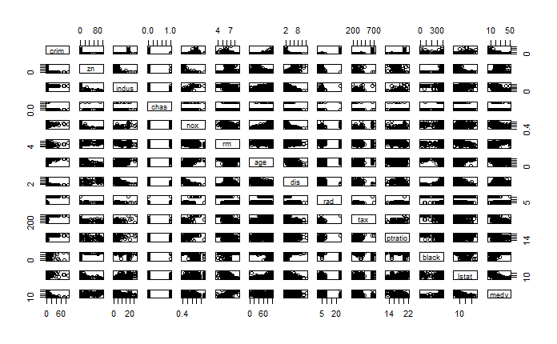

```r
plot(Boston)
```

Summary

```r
summary(Boston)
```

```
      crim                zn             indus            chas
 Min.   : 0.00632   Min.   :  0.00   Min.   : 0.46   Min.   :0.00000
 1st Qu.: 0.08204   1st Qu.:  0.00   1st Qu.: 5.19   1st Qu.:0.00000
 Median : 0.25651   Median :  0.00   Median : 9.69   Median :0.00000
 Mean   : 3.61352   Mean   : 11.36   Mean   :11.14   Mean   :0.06917
 3rd Qu.: 3.67708   3rd Qu.: 12.50   3rd Qu.:18.10   3rd Qu.:0.00000
 Max.   :88.97620   Max.   :100.00   Max.   :27.74   Max.   :1.00000
      nox               rm             age              dis
 Min.   :0.3850   Min.   :3.561   Min.   :  2.90   Min.   : 1.130
 1st Qu.:0.4490   1st Qu.:5.886   1st Qu.: 45.02   1st Qu.: 2.100
 Median :0.5380   Median :6.208   Median : 77.50   Median : 3.207
 Mean   :0.5547   Mean   :6.285   Mean   : 68.57   Mean   : 3.795
 3rd Qu.:0.6240   3rd Qu.:6.623   3rd Qu.: 94.08   3rd Qu.: 5.188
 Max.   :0.8710   Max.   :8.780   Max.   :100.00   Max.   :12.127
      rad              tax           ptratio          black            lstat
 Min.   : 1.000   Min.   :187.0   Min.   :12.60   Min.   :  0.32   Min.   : 1.73
 1st Qu.: 4.000   1st Qu.:279.0   1st Qu.:17.40   1st Qu.:375.38   1st Qu.: 6.95
 Median : 5.000   Median :330.0   Median :19.05   Median :391.44   Median :11.36
 Mean   : 9.549   Mean   :408.2   Mean   :18.46   Mean   :356.67   Mean   :12.65
 3rd Qu.:24.000   3rd Qu.:666.0   3rd Qu.:20.20   3rd Qu.:396.23   3rd Qu.:16.95
 Max.   :24.000   Max.   :711.0   Max.   :22.00   Max.   :396.90   Max.   :37.97
      medv
 Min.   : 5.00
 1st Qu.:17.02
 Median :21.20
 Mean   :22.53
 3rd Qu.:25.00
 Max.   :50.00
```

Zn (proportion of residential land zoned for lots over 25,000 sq.ft) and chas (Charles River dummy variable (= 1 if tract bounds river; 0 otherwise) variables may have data errors or missing data. Let’s see

```r
summary(Boston$zn)
```

```
   Min. 1st Qu.  Median    Mean 3rd Qu.    Max.
   0.00    0.00    0.00   11.36   12.50  100.00
```

There are so many 0.0s , which means towns do not have lots over 25,000 sq.ft.

```r
sort(Boston$zn)
```

[output not shown]

[output cut: 24 more lines]

Chas variable

```r
summary(Boston$chas)
```

```
   Min. 1st Qu.  Median    Mean 3rd Qu.    Max.
0.00000 0.00000 0.00000 0.06917 0.00000 1.00000
```

This variable is categorical (= 1 if tract bounds river; 0 otherwise)

```r
sort(Boston$chas)
```

[output not shown]

Some randomly chosen distributions

Crime rate data distribution

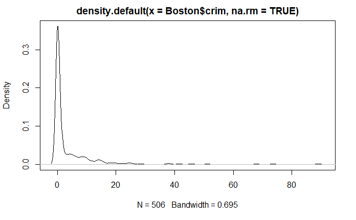

```r
plot(density(Boston$crim,na.rm=TRUE))
```

Age distribution

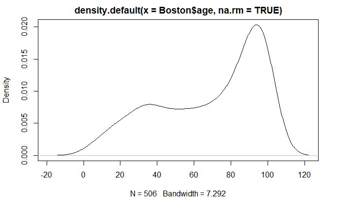

```r
plot(density(Boston$age,na.rm=TRUE))
```

Tax distribution

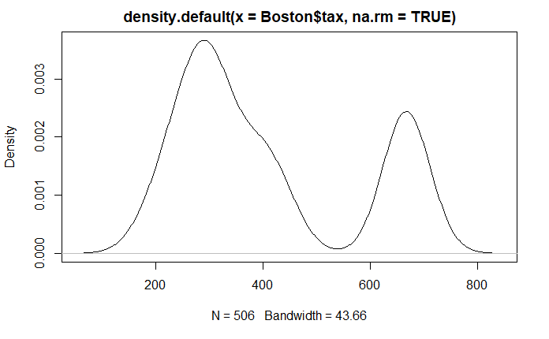

```r
plot(density(Boston$tax,na.rm=TRUE))
```

Perform pairwise scatterplots and describe your findings, such as which pairs show positive correlation, negative correlation, or no correlation?

Correlation of variables

```r
cor(Boston)
```

```
               crim          zn       indus         chas         nox          rm
crim     1.00000000 -0.20046922  0.40658341 -0.055891582  0.42097171 -0.21924670
zn      -0.20046922  1.00000000 -0.53382819 -0.042696719 -0.51660371  0.31199059
indus    0.40658341 -0.53382819  1.00000000  0.062938027  0.76365145 -0.39167585
chas    -0.05589158 -0.04269672  0.06293803  1.000000000  0.09120281  0.09125123
nox      0.42097171 -0.51660371  0.76365145  0.091202807  1.00000000 -0.30218819
rm      -0.21924670  0.31199059 -0.39167585  0.091251225 -0.30218819  1.00000000
age      0.35273425 -0.56953734  0.64477851  0.086517774  0.73147010 -0.24026493
dis     -0.37967009  0.66440822 -0.70802699 -0.099175780 -0.76923011  0.20524621
rad      0.62550515 -0.31194783  0.59512927 -0.007368241  0.61144056 -0.20984667
tax      0.58276431 -0.31456332  0.72076018 -0.035586518  0.66802320 -0.29204783
ptratio  0.28994558 -0.39167855  0.38324756 -0.121515174  0.18893268 -0.35550149
black   -0.38506394  0.17552032 -0.35697654  0.048788485 -0.38005064  0.12806864
lstat    0.45562148 -0.41299457  0.60379972 -0.053929298  0.59087892 -0.61380827
medv    -0.38830461  0.36044534 -0.48372516  0.175260177 -0.42732077  0.69535995
                age         dis          rad         tax    ptratio       black
crim     0.35273425 -0.37967009  0.625505145  0.58276431  0.2899456 -0.38506394
zn      -0.56953734  0.66440822 -0.311947826 -0.31456332 -0.3916785  0.17552032
indus    0.64477851 -0.70802699  0.595129275  0.72076018  0.3832476 -0.35697654
chas     0.08651777 -0.09917578 -0.007368241 -0.03558652 -0.1215152  0.04878848
nox      0.73147010 -0.76923011  0.611440563  0.66802320  0.1889327 -0.38005064
rm      -0.24026493  0.20524621 -0.209846668 -0.29204783 -0.3555015  0.12806864
age      1.00000000 -0.74788054  0.456022452  0.50645559  0.2615150 -0.27353398
dis     -0.74788054  1.00000000 -0.494587930 -0.53443158 -0.2324705  0.29151167
rad      0.45602245 -0.49458793  1.000000000  0.91022819  0.4647412 -0.44441282
tax      0.50645559 -0.53443158  0.910228189  1.00000000  0.4608530 -0.44180801
ptratio  0.26151501 -0.23247054  0.464741179  0.46085304  1.0000000 -0.17738330
black   -0.27353398  0.29151167 -0.444412816 -0.44180801 -0.1773833  1.00000000
lstat    0.60233853 -0.49699583  0.488676335  0.54399341  0.3740443 -0.36608690
medv    -0.37695457  0.24992873 -0.381626231 -0.46853593 -0.5077867  0.33346082
             lstat       medv
crim     0.4556215 -0.3883046
zn      -0.4129946  0.3604453
indus    0.6037997 -0.4837252
chas    -0.0539293  0.1752602
nox      0.5908789 -0.4273208
rm      -0.6138083  0.6953599
age      0.6023385 -0.3769546
dis     -0.4969958  0.2499287
rad      0.4886763 -0.3816262
tax      0.5439934 -0.4685359
ptratio  0.3740443 -0.5077867
black   -0.3660869  0.3334608
lstat    1.0000000 -0.7376627
medv    -0.7376627  1.0000000
```

For this assignment, select one independent (a predictor or X variable) and one dependent variable (a response or Y variable). Explain the objective of selecting these variables. Do the scatter plot of the chosen variables.

I am picking 4 variables: Room, agae, tax and median value of the home

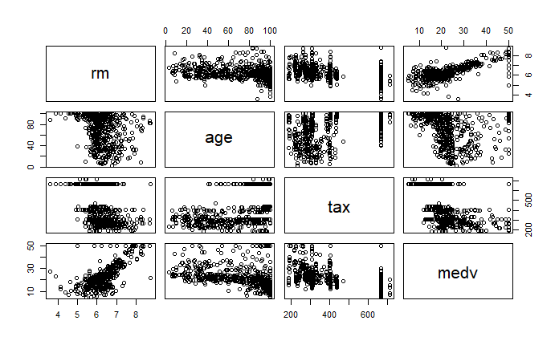

```r
Boston_4 <- subset(Boston, select = c("rm", "age", "tax", "medv"))
plot(Boston_4)
```

Now, I am picking 2 variables out of 4, (age and median home value). I thought it would be good idea to see how age and median value of the house plays out in the data set.

Scatter plot of age and median value of the houses

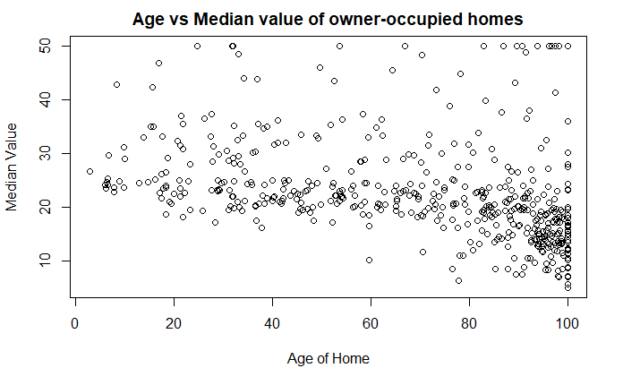

```r
Boston_5 <- subset(Boston, select = c("age", "medv"))
plot(Boston_5, main = "Age vs Median value of owner-occupied homes",
     xlab = "Age of Home",
     ylab = "Median Value")
```

```r
summary(Boston_5)
```

```
      age              medv
 Min.   :  2.90   Min.   : 5.00
 1st Qu.: 45.02   1st Qu.:17.02
 Median : 77.50   Median :21.20
 Mean   : 68.57   Mean   :22.53
 3rd Qu.: 94.08   3rd Qu.:25.00
 Max.   :100.00   Max.   :50.00
```

```r
sort(Boston_5$age)
```

[output not shown]

[output cut: 24 more lines]

Histogram of age

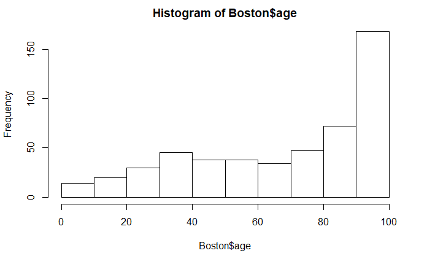

```r
hist(Boston$age)
```

Median value of the houses

```r
sort(Boston_5$medv)
```

[output not shown]

[output cut: 19 more lines]

Histogram of median value of the houses

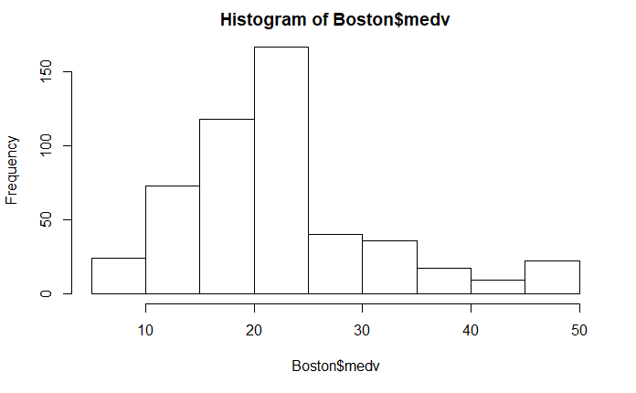

```r
hist(Boston$medv)
```

Age density (skewed to the left)

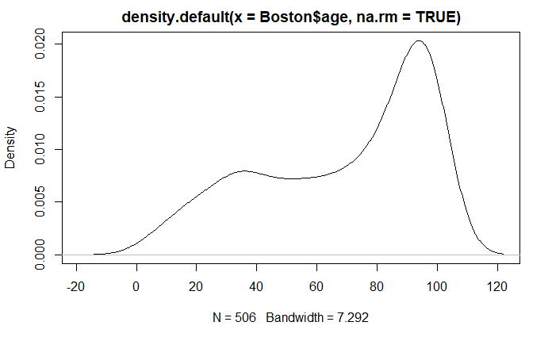

```r
plot(density(Boston$age,na.rm=TRUE))
```

Density of median value (skewed to the right)

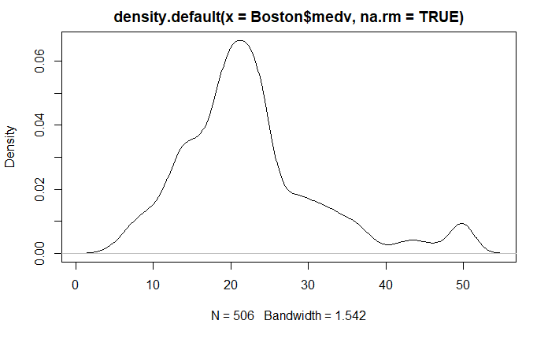

```r
plot(density(Boston$medv,na.rm=TRUE))
```

Now, perform linear regression on variables that you chose from step 4 using 5% significance level (or 95% confidence level). State both the null and the alternative hypothesis:

```
H0: There is no relationship between age of the house and median value of the house

H1:There is some relationship between age and median value
```

Show the linear regression command in R and the corresponding results.

```r
Boston_5.lm <- lm(age ~ medv, Boston_5) # save all outputs to an object
#The model formula is = intercept_coefficient + coefficient_var1*var1
```

Calculate, and interpret parameters such as slope and coefficient of determination

```r
Boston_5.lm
```

```
Call:
lm(formula = age ~ medv, data = Boston_5)

Coefficients:
(Intercept)         medv
     94.571       -1.154
```

Summarize the model fitting Coefficient of determination

```r
summary(Boston_5.lm)$r.squared # This is the coefficient of determination
```

```
[1] 0.1420947
```

Correlation coefficient. It is negative so it has negative linear correlation.

```r
cor(Boston_5,
    use = "all.obs", # Specifies the handling of missing data. Options are all.obs (assumes no missing data - missing data will produce an error), complete.obs (listwise deletion), and pairwise.complete.obs (pairwise deletion)
    method = "pearson" # Specifies the type of correlation. Options are pearson, spearman or kendall.
      )
```

```
            age       medv
age   1.0000000 -0.3769546
medv -0.3769546  1.0000000
```

p-value is the probability the correlation is because of random chance. Low p-value means reject the null hypothesis.

```r
summary(Boston_5.lm)
```

```
Call:
lm(formula = age ~ medv, data = Boston_5)

Residuals:
   Min     1Q Median     3Q    Max
-61.37 -21.37   7.31  18.94  63.11

Coefficients:
            Estimate Std. Error t value Pr(>|t|)
(Intercept)  94.5713     3.0728  30.777   <2e-16 ***
medv         -1.1537     0.1263  -9.137   <2e-16 ***
---
Signif. codes:  0 *** 0.001 ** 0.01 * 0.05 . 0.1   1

Residual standard error: 26.1 on 504 degrees of freedom
Multiple R-squared:  0.1421,    Adjusted R-squared:  0.1404
F-statistic: 83.48 on 1 and 504 DF,  p-value: < 2.2e-16
```

```r
t.test(Boston_5)
```

```
    One Sample t-test

data:  Boston_5
t = 46.565, df = 1011, p-value < 2.2e-16
alternative hypothesis: true mean is not equal to 0
95 percent confidence interval:
 43.63415 47.47356
sample estimates:
mean of x
 45.55385
```

Explain how do you read the result. Do you accept or reject the null hypothesis? Why? Discuss.

Answer: Since p-value is so low we can reject null hypothesis.

Is there any evidence of a linear relationship between the predictor and response variable that you chose? Explain.

Answer: Correlation coefficient is negative so it has negative linear correlation.

Verify the model assumptions (e.g. linearity, normality, variance) and specify which assumptions do not hold, if there is any.

```r
shapiro.test(Boston_5$age)
```

```
    Shapiro-Wilk normality test

data:  Boston_5$age
W = 0.89201, p-value < 2.2e-16
```

```r
shapiro.test(Boston_5$medv)
```

```
    Shapiro-Wilk normality test

data:  Boston_5$medv
W = 0.91718, p-value = 4.941e-16
```

Provide insights/findings from the exercise. Address any other concerns you might have.

Answer: The analysis shows that age of the house and median value of the house has negative linear correlation. It means that as age of the house increases the median value of the house decreases and vice versa.